# credit_score

The problem targeted at this Machine Learning exercise is to predict creditworthiness of a client at a German Bank, based on 20 quantitative and qualitative characteristics of a client.

Based on historical records, clients fall into two categories:

- ‘good’, i.e. credit-worthy clients, who would most probably repay credit.
- ‘bad’, most probably would not repay.

The cost of the ‘wrong’ decision, i.e. giving credit to a client who would not return it, is higher. This cost should be incorporated via ‘cost matrix’, specifying that such a mistake is 5 times costlier (can be any number higher than 1).

The data can be found at UCI Machine Learning repository.

## Motivation for exploring the problem in R

This machine learning exercise is going to be coded in Python, as Python’s `scikit-learn`, in general, is more powerful in model tuning than R. However, prior to doing that, an attempt is made to quickly explore the data set in R for the following reasons:

- to get acquainted with salient characteristics of the data and visualize data
- develop a feeling what accuracy could be for a range of simple algorithms in R
- try different coding schemes for class variables, namely:
  - grouping them together
  - coding them separately as dummy variables
- explore what effect penalty cost-matrix can have on results
- explore directions for further model tuning:
  - is collinearity present among features?
  - are there non-informative features in the data set?
  - what kind of feature engineering could be attempted?

## Load data into R

First we need to load data into R and assign names to features, as the data set does not have header.

Note, that category codings (‘A5’, ‘A13’ etc) are appended to numerical features, whereas categorical features are appended with “_”. The latter will ease reading names of the features when dummies are expanded and dummy labels (‘A101’, ‘A72’ etc) are appended after “_”. The meaning of ’A**’ labels can be found at this page.

As example:

- `num_duration_A2` means ‘duration in month’
- `chk_account_A12` would mean application between 0 and DM200.

```r
source('./functions/plotImp.R')    # for plotting variable importance
library(SIT)                       # for `spl` function

# enter feature names
.names <- spl("chk_account_,num_duration_A2,history_,purpose_,num_amount_A5,svn_account_,empl_status_,num_income_share_A8,marital_status_,guarantor_,num_residence_A11,property_,num_age_A13,other_loans_,housing_,num_credits_A16,job_,num_dependants_A18,telephone_,foreign_,status")

# make vector of .colClasses
.num         <- grepl('^num_', .names)  # search for numeric data
.colClasses  <- ifelse(.num, "numeric", "factor")

# read data into R
raw <- read.table(file="./data/german.data",
                  header=F,
                  col.names = .names,
                  colClasses = .colClasses)
```

## Explore data

Let’s start our data exploration with assigning outcome labels ‘good’/‘bad’ to 1/2 coded status variable and checking composition of our data set.

```r
levels(raw$status) <- c('good', 'bad')
summary(raw$status)
```

```
## good  bad
##  700  300
```

There are two conclusions here:

- the data set is slightly unbalanced
- the base accuracy, that is always assigning majority class to outcome event, is 0.7. In banking parlor base accuracy is the probability of always advancing a credit, irregardless of client’s profile. This is the figure we will target to improve upon.

Both application duration and the amount of money asked for are right-skewed.

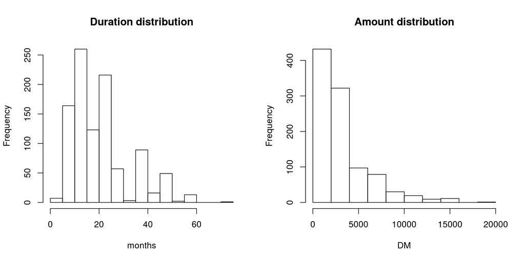

```r
par(mfrow=c(1,2))
hist(raw$num_duration_A2, main='Duration distribution', xlab='months')
hist(raw$num_amount_A5, main='Amount distribution', xlab = 'DM')
```

Searching for what constitutes the bulk of the applications:

```r
quantile(raw$num_amount_A5, .8)
```

```
##  80%
## 4720
```

```r
library(dplyr)
rawSorted <- filter(raw, num_amount_A5 > quantile(num_amount_A5,.8))
median(rawSorted$num_duration_A2)
```

```
## [1] 36
```

we will conclude that 80% of the applications are for the sums under DM 5’000 and duration below 36 months.

## Split train/test

To train hypeparameters of ML algos and to check generalization ability of our models we need to split `raw` data set into train/test subsets.

NOTE:

There are two sets showing two possible representations of the same features:

- `xTrain`, the set where categorical features are expanded explicitly and coded as 0/1 dummies.
- `xTrainG`, the set where categorical features are grouped (kept together as character strings). This possibility is due to specific treatment of grouped categorical variables by trees when they are provided as x/y separately, as opposed to formula representation (see Max Kuhn, ‘Applied Predictive Modeling’, Ch.14, for extended discussion)

```r
# dummies expanded explicitly
.x <- model.matrix(~.-1, data=raw[,-21])
.y <- raw[,21]


library(caTools)
set.seed(1)
ind   <- sample.split(raw$status, SplitRatio = .7)

xTrain <- .x[ ind,]
xTest  <- .x[!ind,]

yTrain <- .y[ ind]
yTest  <- .y[!ind]

# grouped categorical variables for trees methods RF, C5.0 etc.
xTrainG <- raw[ ind,-21]
xTestG  <- raw[!ind,-21]
```

## Building models

Below I will build several ensemble models, including Random Forest, boosted trees, and C5.0, providing rational for using a particular method. All the models will be built on both grouped and separate feature data sets comparing model performance side by side. All of these are non-linear, highly-performant black boxes, that provide most accurate predictions while giving little insight into what should drive a credit officer’s decision making process.

I will conclude with a regularized logistic regression, less accurate, but more interpretable.

### Random Forest

Decision trees, as a class of statistical learning algorithms, are powerful and popular tools that suffer from high variability: if we sample a slightly different data set, splitting rules may change completely. That was overcome by bagging many trees at once (default in R is 500), and averaging the outcome in a black box called Random Forest.

Below is an example of tuning Random Forest from `randomForest` package via `caret` function `train`.

Training model (tuning hyperparameters via cross-validation) is a time-consuming process. This is why I turn on multi-threading and run R process on 2 cores:

```r
library(doMC)
registerDoMC(2)     # 2 cores
library(caret)
```

Then, let’s build a train control, which will be used across all the models for consistency, tune grid for RF, and train the model.

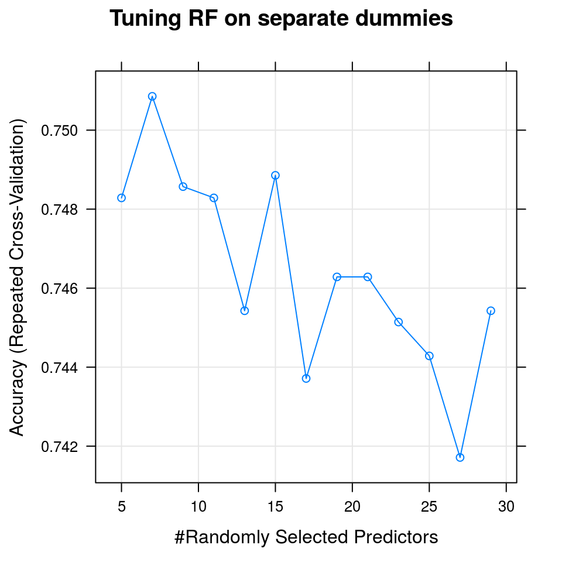

```r
ctrl   <- trainControl(method = 'repeatedcv', # 10-fold 5-repeats cv
                       number=10,
                       repeats=5,
                       allowParallel = T)        # parallelize execution

gridRF   <- expand.grid(mtry=seq(5,30,by=2))     # training grid, # of features to split upon

set.seed(1)         # to ensure consistency in sampling across all models
mod_rf <- train(x = xTrain,
                y = yTrain,
                method    ='rf',
                tuneGrid  = gridRF,
                trControl = ctrl)

plot(mod_rf, main='Tuning RF on separate dummies')
```

It appears that best result is achieved at 7 splits.

Before I will proceed further it’s worth noting that there is no need to memorize the list of all possible models and tuning parameters for a particular model.

```r
names(getModelInfo())
```

```
##   [1] "ada"                 "AdaBag"              "AdaBoost.M1"
##   [4] "amdai"               "ANFIS"               "avNNet"
##   [7] "bag"                 "bagEarth"            "bagEarthGCV"
##  [10] "bagFDA"              "bagFDAGCV"           "bayesglm"
##  [13] "bdk"                 "binda"               "blackboost"
##  [16] "Boruta"              "brnn"                "bstLs"
##  [19] "bstSm"               "bstTree"             "C5.0"
##  [22] "C5.0Cost"            "C5.0Rules"           "C5.0Tree"
##  [25] "cforest"             "chaid"               "CSimca"
##  [28] "ctree"               "ctree2"              "cubist"
##  [31] "DENFIS"              "dnn"                 "earth"
##  [34] "elm"                 "enet"                "enpls.fs"
##  [37] "enpls"               "evtree"              "extraTrees"
##  [40] "fda"                 "FH.GBML"             "FIR.DM"
##  [43] "foba"                "FRBCS.CHI"           "FRBCS.W"
```

[output cut: 46 more lines]

As one can see, at the time of this writing, there are about 183 models (a.k.a. methods) available in `caret` package.

```r
modelLookup('rf')
```

```
##   model parameter                         label forReg forClass probModel
## 1    rf      mtry #Randomly Selected Predictors   TRUE     TRUE      TRUE
```

The outcome of this command shows that:

- method `rf` is suitable for both regression and classification
- there is a single tuning parameter `mtry`

Next, let’s initiate an object that will hold all the models:

```r
models    <- list()
models$rf <- mod_rf
```

To finish with Random forest, let’s train the same model on grouped `xTrainG`, i.e. grouped features:

```r
set.seed(1)
mod_rfG <- train(x = xTrainG,
                 y = yTrain,
                 method    ='rf',
                 tuneGrid  = gridRF,
                 trControl = ctrl)

models$rfG <- mod_rfG
```

### Boosted trees

Boosted trees are another ensemble method that overcome high variability of a single decision tree (a ‘weak’ learner) by gradual learning from misclassification. It resembles Random Forest in that boosting combines predictions from many trees. However, unlike Random Forest, at each sampling boosting assigns more weight to misclassified samples.

Below is implementation of model tuning of boosted tree from `gbm` package. First I train on separate dummies.

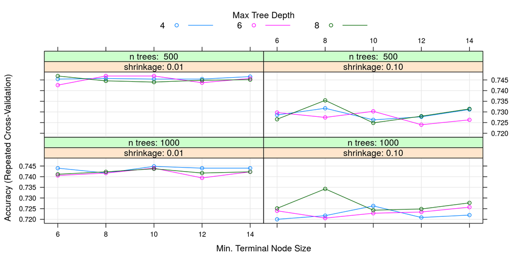

```r
gbmGrid <- expand.grid(interaction.depth = c(4,6,8),
                       n.trees = c(500,1000),
                       shrinkage = c(0.01,0.1),
                       n.minobsinnode=c(6,8,10,12,14))

set.seed(1)
mod_gbm <- train(x = xTrain,
                 y = yTrain,
                 method='gbm',
                 tuneGrid = gbmGrid,
                 verbose=F,
                 trControl = ctrl)

models$gbm <- mod_gbm
plot(mod_gbm)
```

Next, boosted trees on grouped variables:

```r
set.seed(1)
mod_gbmG <- train(x = xTrainG,
                  y = yTrain,
                  method='gbm',
                  tuneGrid = gbmGrid,
                  verbose=F,
                  trControl = ctrl)

models$gbmG <- mod_gbmG
```

### C5.0

C5.0 is an example of a rule based tree.

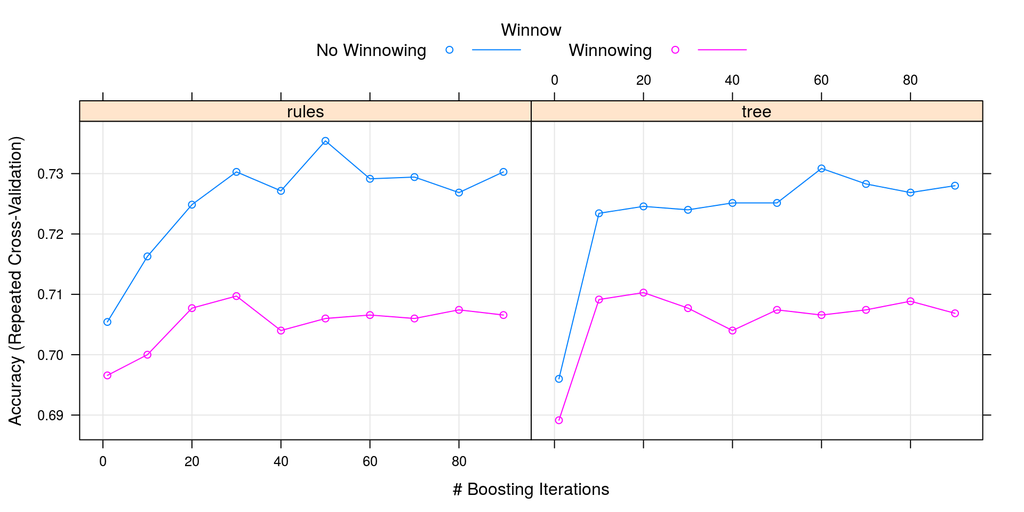

```r
set.seed(1)
c5_mod <- train(x = xTrain,
                y = yTrain,
                method     = "C5.0",
                tuneLength = 10,
                trControl  = ctrl)

models$c5 <- c5_mod
plot(c5_mod)
```

```r
set.seed(1)
c5_modG <- train(x = xTrainG,
                 y = yTrain,
                 method     = "C5.0",
                 tuneLength = 10,
                 trControl  = ctrl)

models$c5G <- c5_modG
```

## Results of model fitting

Let’s present the results of model fitting and answer the following questions that we formulated at the onset of this exercise:

- **In-sample cross-validation**:
  - which models do better perform in-sample based on cross-validated results? This is important for assessing generalization ability of the models.
- **Out-of-sample validation**:
  - which models do better perform on held-out test sample? This is another, more direct shot at generalization ability.
- **Feature importance**:
  - what are the most important features? Do different models concur on what are the most important features in advancing a credit?
- **Feature interpretation**:
  - what are the positive/negative signs of creditworthiness?

### In-sample cross-validation

At this time we have `models` object that contains all our models. The models that are objects of class `train`, among other things, held results of in-sample cross-validation on held-out resamples.

Because resamples are the same for all models, which was ensured by:

1. common `ctrl` objects and
2. setting the same seed prior to resampling

we have the full right to assess the results of resampling via the following commands:

```r
resamp <- resamples(models)
summary(resamp, metric='Accuracy')
```

```
##
## Call:
## summary.resamples(object = resamp, metric = "Accuracy")
##
## Models: rf, rfG, gbm, gbmG, c5, c5G
## Number of resamples: 50
##
## Accuracy
##        Min. 1st Qu. Median   Mean 3rd Qu.   Max. NA's
## rf   0.6857  0.7286 0.7429 0.7509  0.7714 0.8429    0
## rfG  0.6714  0.7429 0.7571 0.7597  0.7857 0.8429    0
## gbm  0.6714  0.7143 0.7429 0.7469  0.7821 0.8571    0
## gbmG 0.6429  0.7286 0.7500 0.7543  0.7857 0.8429    0
## c5   0.6000  0.7000 0.7429 0.7354  0.7679 0.8286    0
## c5G  0.6143  0.7143 0.7429 0.7471  0.7857 0.8429    0
```

Again, this is a meaningful procedure, because resamples are the same across all models.

NOTE:  
we can even do a pairwise comparison of resampling results via `summary(diff(resamp))`, which will assess if the models produce results that are statistically different. But that is not of interest here.

We can visualize model performance as follows:

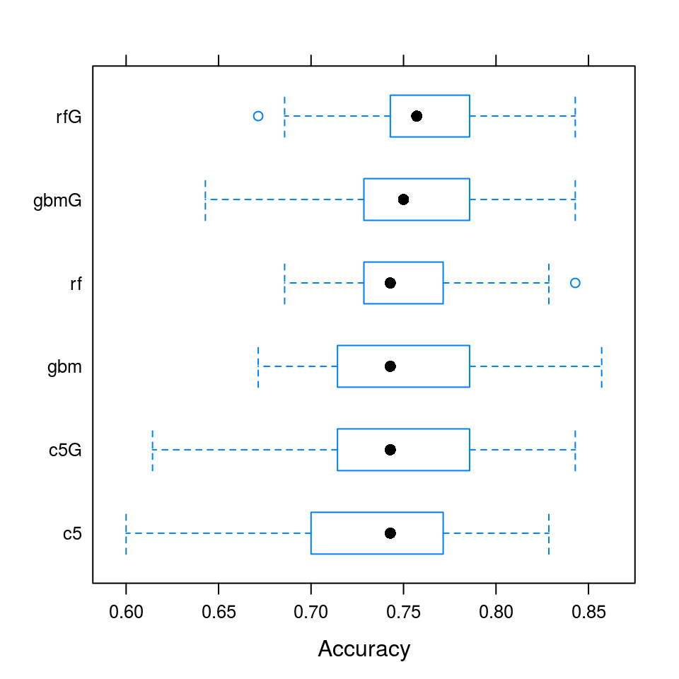

```r
bwplot(resamp, metric='Accuracy')
```

### Out-of-sample validation

In-sample cross-validation is good for tuning hyperparameters. However, due to cherry-picking, generalization ability measured by such cross-validation is biased upward.

A fairer approach would be checking how our models perform on samples that they never saw before, i.e. on held-out samples that were set aside at the beginning of the exercise (see Split train/test section)

```r
accuracy <- vector(mode='numeric')

for (i in names(models)) {
    if (grepl('G$', i)) {
        accuracy[i] <- mean(predict(models[[i]], xTestG) == yTest)
    } else {
        accuracy[i] <- mean(predict(models[[i]], xTest ) == yTest)
        }
}

accuracy
```

```
##        rf       rfG       gbm      gbmG        c5       c5G
## 0.7766667 0.7833333 0.7733333 0.7766667 0.7766667 0.7833333
```

We will visualize accuracies obtained:

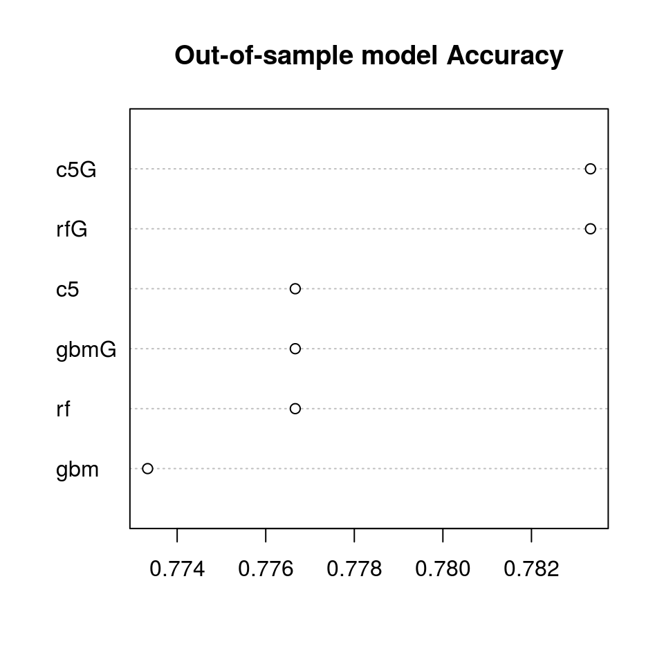

```r
dotchart(sort(accuracy), main="Out-of-sample model Accuracy")
```

### Feature importance

Another important step in interpreting the models is checking for consistency among models for most important features.

To do so, let’s extract feature importance with the help of caret’s function `varImp` and then plot top 10 features, side by side, with the help of custom made `plotImp` funcion. This is a pretty wrapper for base R’s `dotchart` function.

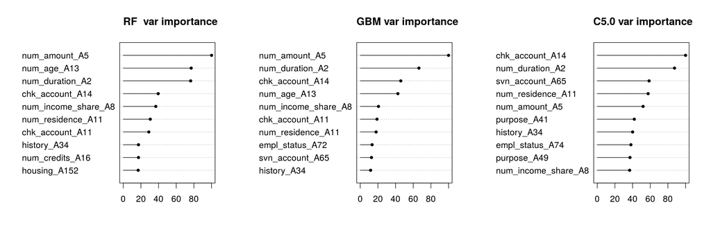

```r
par(mfrow=c(1,3))
rf_imp   <- varImp(models$rf )
gbm_imp  <- varImp(models$gbm)
c5_imp   <- varImp(models$c5 , metric='splits')
plotImp(rf_imp,  main = '  RF  var importance', cex=1.1)
plotImp(gbm_imp, main = '  GBM var importance', cex=1.1)
plotImp(c5_imp,  main = ' C5.0 var importance', cex=1.1)
```

### Feature interpretation

Even though the above plots show consistency among models for what are considered to be the most important features, we still have no idea if big or small `num_account_A5`, which is credit amount asked for, is a sign of positive or negative credit decision. In other words, interpretability of the ensemble black boxes is very low.

To overcome low interpretability let’s build a regularized logistic model via `glmnet` package that will be trained by caret’s `train`

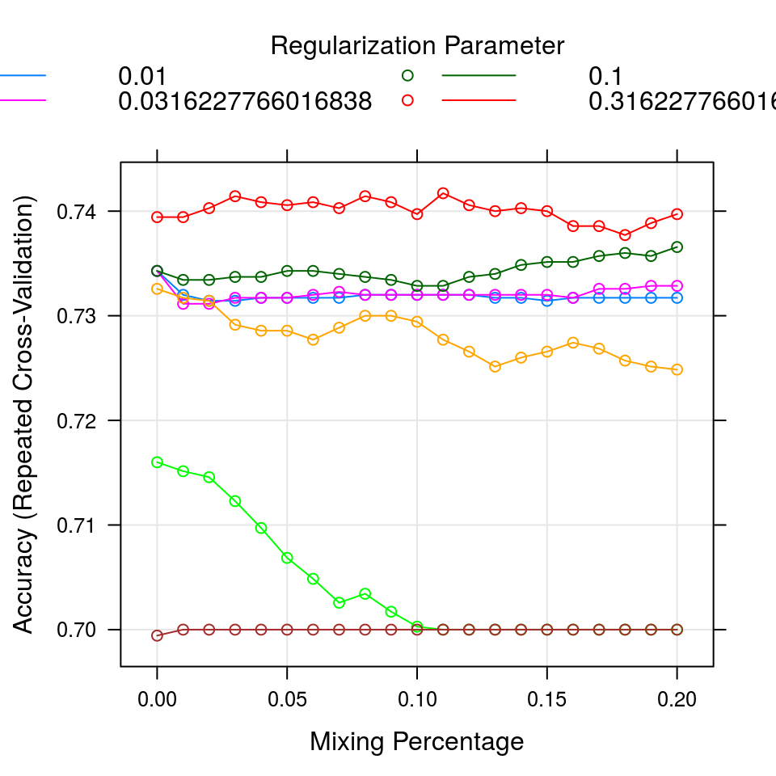

```r
grid <- expand.grid(alpha = seq(0,.2,by=.01),
                    lambda = 10^(seq(-3,0,by=.5)))

set.seed(1)
glmnet_mod <- train(x = xTrain,
                    y = yTrain,
                    method = "glmnet",
                    tuneGrid = grid,
                    preProcess = c('center', 'scale'), # to ensure fair regularization
                    trControl = ctrl)

plot(glmnet_mod)
```

To continue in parallel with our previous focus on feature importance, let’s define the features, that are left after normalization and regularization with biggest coefficients, to be most important (i.e. outcome is most sensitive to changes in these features).

NOTE:  
as of now, `glmnet` function does not produce scores for statistical significance of the coefficients, only regularized values.

Let’s plot the so-defined most ‘important’ features:

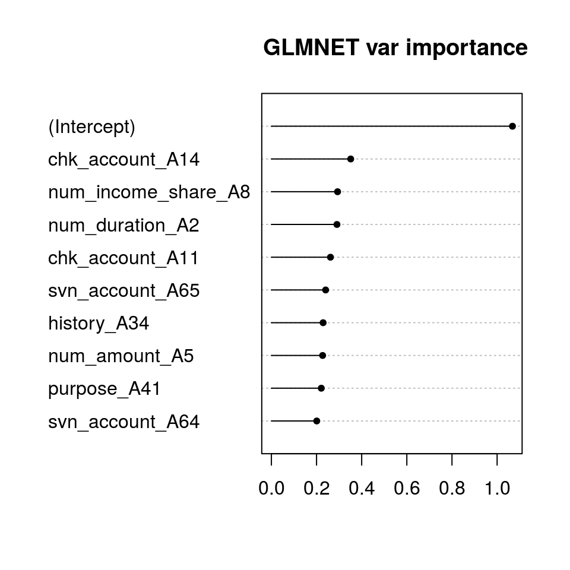

```r
coefGLM <- coef(glmnet_mod$finalModel, glmnet_mod$bestTune$lambda)
glm_imp <- list()
glm_imp$importance <- abs(coefGLM[order(abs(coefGLM), decreasing = T),])
plotImp(glm_imp, main = ' GLMNET var importance')
```

Now we can see a significant overlap between non-linear tree ensemble methods (RF, gbm, C5.0 above) and linear logistic regression, which is a very assuring sign!

Let’s print out top 10 coefficients, to see the signs of the coefficients, and ultimately to understand how most important features affect credit decision:

```r
coefGLM[order(abs(coefGLM), decreasing = T),][1:10]
```

```
##         (Intercept)     chk_account_A14 num_income_share_A8
##          -1.0680333          -0.3513805           0.2931871
##     num_duration_A2     chk_account_A11     svn_account_A65
##           0.2904506           0.2617197          -0.2403409
##         history_A34       num_amount_A5         purpose_A41
##          -0.2291794           0.2270560          -0.2210416
##     svn_account_A64
##          -0.2008976
```

With this information we are ready to wrap up our analysis, to draw conclusions, and to map our way forward in Python